# Линейный классификатор

$X$ - пространство объектов;  
$Y$ - пространство ответов;  
$y: X \rightarrow Y$ - неизвестная функция.

**Дано:**  
$\{x_1, \ldots, x_l\}\subset X$ - обучающая выборка (training sample);  
$y_i=y(x_i), i=1,\ldots,l$ - известные ответы.

**Найти:**  
$a: X \rightarrow Y$ - алгоритм, приближающий $y$ на всем множестве $X$.

Будем рассматривать задачу бинарной классификации.

**Идея:** найдем гиперплоскость, разделяющую объекты в признаковом пространстве на две полуплоскости, в каждой из которых находятся объекты одного класса.

[figure not shown]

Как задается гиперплоскость?

$$ w_0 + x_1w_1 + x_2w_2 + \ldots + x_nw_n = 0 $$

Поэтому классификатор можно задать следующим образом:

$$ a(\bar{x}) = sign\big(\langle\bar{w},\bar{x}\rangle+w_0 \big) $$

**Margin.** Будем называть величину $M_i = y_i(\langle\bar{w}, \bar{x}_i\rangle + w_0)$ отступом объекта. Чем больше отступ, тем больше объект "погружен" в свой класс.

[figure not shown]

$$ \begin{cases} ||w||^2\rightarrow \min_{w, w_0}, \\ y_i(\langle w, x\rangle+w_0) \ge 1, i=1,\ldots,l \end{cases} $$

Линейно неразделимая выборка

[figure not shown]

$$ \begin{cases} \frac{1}{2}||w||^2 + C\sum_{i=1}^l\xi_i \rightarrow \min_{w, w_0, \xi}, \\ y_i(\langle w, x\rangle+w_0) \ge 1-\xi_i,\ i=1,\ldots,l \\ \xi_i\ge0,\ i=1,\ldots,l \end{cases} $$

Можно перейти к оптимизационной задаче

$$ C\sum_{i=1}^l(1-M_i(w, w_0))_{+}+\frac{1}{2}||w||^2 \rightarrow \min_{w,w_0}, $$

а от нее к

$$ \begin{cases} -\sum_{i=1}^l\lambda_i+\frac{1}{2}\sum_{i=1}^l\sum_{j=1}^l\lambda_i\lambda_jy_iy_j\langle x_i, x_j\rangle\rightarrow\min_\lambda, \\ 0\le\lambda_i\le C,\ i=1,\ldots,l,\\ \sum_{i=1}^l\lambda_iy_i=0 \end{cases} $$

Решение находится в виде $$ \begin{cases} w=\sum_{i=1}^l\lambda_iy_ix_i \\ w_0 = \langle w, x_i \rangle - y_i,\ i: \lambda_i>0, M_i=1 \end{cases} $$

Типизация объектов:

- неинформативные объекты ($\lambda_i=0,\ \xi_i=0,\ M_i>1$);
- опорные граничные объекты ($0<\lambda_i$, $\xi_i=0,\ M_i=1$);
- опорные нарушители ($\lambda_i=C,\ \xi_i>0,\ M_i<1$)

Итого

$$ a(x) = sign\big(\sum_{i=1}^l\lambda_iy_i\langle x_i, x\rangle+w_0\big) $$

Можно сказать, что мы вводим новые признаки - скалярные произведения с опорными векторами: $f'_i(x)=\langle x_i, x\rangle$.

**Идея:** а что, если заменить скалярное произведение на какую-то другую функцию?

$$ a(x) = sign\big(\sum_{i=1}^ly_i\lambda_i\ \mathbf{\big\langle x_i, x\big\rangle}\ +w_0\big) $$

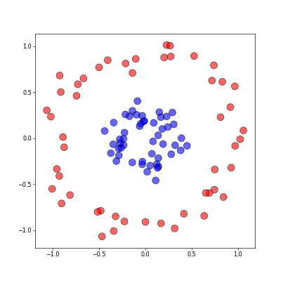

```python
X, y = make_circles(noise=0.1, factor=0.3, random_state=1)
plt.figure(figsize=(7, 7))
plt.scatter(X[:, 0], X[:, 1], c=y, cmap=cm_bright, alpha=0.6, edgecolors='k', s=150);
```

```python
X_new = np.hstack((X, np.sum(X**2, axis=1, keepdims=True)))
```

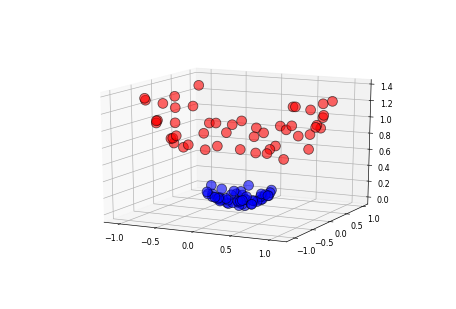

```python
%matplotlib notebook
%matplotlib notebook
ax = plt.figure().add_subplot(111, projection='3d')
ax.scatter(X_new[:, 0], X_new[:, 1], X_new[:, 2], c=y, cmap=cm_bright, alpha=0.6, edgecolors='k', s=150);
```

Оказывается, что если вместо скалярного произведения взять функцию $K: X\times X\rightarrow R$, которая обладает некоторыми свойствами, то ее можно подставить вместо скалярного произведения во всех предыдущих выкладках.

$$ a(x) = sign\big(\sum_{i=1}^ly_i\lambda_i\ \mathbf{K(x_i, x)}\ +w_0\big) $$

Такие функции называются **ядрами**.

**Определение.** Ядро - функция $K: X\times X\rightarrow R$ такая, что $K(x, x')=\langle\phi(x), \phi(x')\rangle$ при некотором $\phi: X\rightarrow H$, где $H$ - некоторое пространство.

Пространство $H$ называется спрямляющим пространством.

**Теорема.** $K(x, x')$ - ядро тогда и только тогда, когда она симметична $K(x, x')=K(x', x)$ и неотрицательно определена $\int_X\int_XK(x, x')g(x)g(x')dxdx'\ge0$ для любой $g: X\rightarrow R$.

Есть различные способы конструировать ядра:

- $K(x, x')=\langle x, x'\rangle$ - ядро;
- $K(x, x')=1$ - ядро;
- $K(x, x')=K_1(x, x')K_2(x, x')$ - ядро;
- для $\psi: X\rightarrow R$ произведение $K(x, x')=\psi(x)\psi(x')$ - ядро;
- $K(x, x')=\alpha_1K_1(x, x')+\alpha_2K_2(x, x')$ при $\alpha_1,\alpha_2>0$ - ядро;
- для $\psi:X\rightarrow X$ если $K_0$ - ядро, то $K(x, x')=K_0(\psi(x), \psi(x'))$ - ядро;
- если $K_0$ - ядро и функция $f:R\rightarrow R$ представима в виде сходящегося степенного ряда с неотрицательными коэффициентами, то $K(x, x')=f(K_0(x, x'))$ - ядро.

**Пример:** Пусть $X=R^2$, $K(u,v)=\langle u, v\rangle^2$, где $u=(u_1, u_2)$, $v=(v_1, v_2)$. Найти пространство $H$ и преобразование $\phi: X\rightarrow H$, при которых $K(x, x')=\langle\phi(x), \phi(x')\rangle_H$.

$$ K(u, v) = \langle u, v\rangle^2=(u_1v_1+u_2v_2)^2=u_1^2v_1^2+u_2^2v_2^2+2u_1v_1u_2v_2=\langle(u_1^2, u_2^2, \sqrt{2}u_1u_2), (v_1^2, v_2^2, \sqrt{2}v_1v_2)\rangle $$

Поэтому $H=R^3, \phi:(u_1, u_2)\rightarrow(u_1^2, u_2^2, \sqrt{2}u_1u_2)$.

```python
X_quadro = np.hstack((X**2, np.sqrt(2) * np.prod(X, axis=1, keepdims=1)))
```

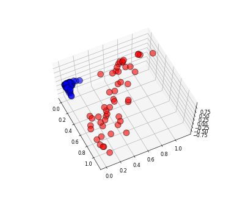

```python
ax = plt.figure().add_subplot(111, projection='3d')
ax.scatter(X_quadro[:, 0], X_quadro[:, 1], X_quadro[:, 2], c=y, cmap=cm_bright, alpha=0.6, edgecolors='k', s=150);
```

Стандартный набор ядер:

- $K(x, x')=\langle x, x'\rangle^2$ - квадратичное ядро (в исходном пространстве выборку разделяет квадратичная поверхность);
- $K(x, x')=\langle x, x'\rangle^d$ - полиномиальное ядро с мономами степени $d$;
- $K(x, x')=(\langle x, x'\rangle+1)^d$ - полиномиальное ядро с мономами степени $\le d$;
- $K(x, x')=\exp(\gamma||x-x'||^2)$ - RBF (Radial basis function);

[figure not shown]

Таким образом, для построения классификатора необходимо подбирать ядра и их коэффициенты, а также коэффициент регуляризации.

$$ C\sum_{i=1}^l(1-M_i(w, w_0))_{+}+\frac{1}{2}||w||^2 \rightarrow \min_{w,w_0}, $$

[figure not shown]

По умолчанию используется RBF-ядро - предел последовательности полиномиальных ядер (при $d\rightarrow\infty$).

$K(x, x')=\exp(\gamma||x-x'||^2)$, $\gamma$ - параметр сглаживания.

[figure not shown]

Метод опорных векторов есть в [sklearn](http://scikit-learn.org/stable/modules/generated/sklearn.svm.SVC.html).

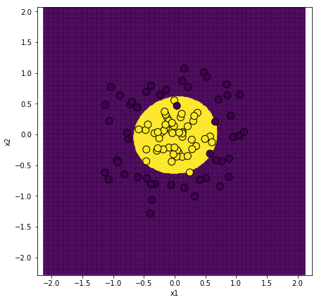

```python
%matplotlib inline
X, y = make_circles(noise=0.2, factor=0.3, random_state=1)
svc = SVC()
plot_model_predict(X, y, svc)
```